# Noções Básicas de R - Aula 7

# data.frame

Generalização dos vetores no sentido de que uma data.frame é uma coleção de objetos de tipos os mais variados, mas **todos do mesmo tamanho**.  
São vetores formando dataframes, matrizes que permitem que suas colunas tenham diferentes tipos de variáveis <chr> <int> <flt> <fctr> <Date> etc.  
Usados para guardar tabelas de dados de um problema qualquer.  
Suas colunas tem nomes e podem conter dados de tipos diferentes, diferindo de uma matriz.  
Cada registro da BD corresponde a uma linha da data.frame e cada coluna a uma variável, campo ou propriedade das observações coletadas.  
Podem ser criadas pela função data.table()

```r
#Criando uma função para encontrar a média e o DP de um <vctr> ou de uma <mtrx>.
#Esses valores retornarão após o último elemento do <vctr>
#Se for uma <mtrx> retornarão por linha (row=TRUE) após sua última coluna.
#ou por coluna (col=TRUE) após a última linha da <mtrx>.
media_dp<-function(m,dp=TRUE,row=TRUE,col=TRUE) {
  if(is.vector(m)) {
    n<-length(m)
    m[n+1]<-mean(m,na.rm = TRUE)
    if(dp==TRUE) {
      m[n+2]<-sd(m[1:n],na.rm = TRUE)
    }#fim do if(dp==TRUE)
    return(m)
  #fim do if is.vector(m)
  } else {
    l<-nrow(m)
    c<-ncol(m)

  if(is.matrix(m)) {
    if(row==TRUE) {
      # A linha seguinte é para evitar o erro: Error in `[<-`(`*tmp*`, i, c + 1, value = 79.8) : subscript out of bounds
      m<-cbind(m,matrix(data = NA, nrow = l, ncol = 2, byrow =   FALSE,dimnames = NULL))
      for (i in 1:l) {
        m[i,c+1]<-mean(m[i,],na.rm = TRUE)
        if(dp==TRUE){m[i,c+2]<-sd(m[i,1:c],na.rm = TRUE)}#fim do if
      }#fim do for para calcular média e DP de cada linha
    }#fim do if (row==TRUE)
    if(col==TRUE) {
      # A linha seguinte é para evitar o erro: Error in `[<-`(`*tmp*`, i, c + 1, value = 79.8) : subscript out of bounds
      m<-rbind(m,matrix(data = NA, nrow = 2, ncol = c, byrow =   FALSE,dimnames = NULL))
      for (j in 1:c) {
        m[l+1,j]<-mean(m[,j],na.rm = TRUE)
        if(dp==TRUE){m[l+2,j]<-sd(m[1:l,j],na.rm = TRUE)}#fim do if
      }#fim do for para calcular média e DP de cada coluna
    }#fim do if (col==TRUE)
    return(m)
  }#fim do if is.matrix(m)
 }#fim do else do if is.vector(m)
}#fim da function media_dp()
```

# Linguagem R: importância de explorar a sua funcionalidade e a sua orientação a objeto

```r
getwd()
```

```
## [1] "C:/Users/Cleuler/Documents/aulas/07-aula"
```

```r
load("dados.RData")
names(dados)<-tolower(names(dados)) # recodifica os nomes das variáveis para minúsculas

#Inspecionando os dados da nossa BD
#Calculando a altura média da turma e seu desvio padrão
dados$altura
```

```
##  [1] 1.70 1.74 1.63 1.77 1.83 1.75 1.61 1.85 1.60 1.59 1.55 1.70 1.63 1.70
## [15] 1.75
```

```r
dados$altura[dados$sexo=="m"] # são 10 pessoas do sexo masculino
```

```
##  [1] 1.70 1.74 1.63 1.77 1.83 1.75 1.85 1.70 1.70 1.75
```

```r
dados$altura[dados$sexo=="f"] # são  5 pessoas do sexo feminino
```

```
## [1] 1.61 1.60 1.59 1.55 1.63
```

```r
media_dp(m = dados$altura,dp = TRUE)
```

```
##  [1] 1.70000000 1.74000000 1.63000000 1.77000000 1.83000000 1.75000000
##  [7] 1.61000000 1.85000000 1.60000000 1.59000000 1.55000000 1.70000000
## [13] 1.63000000 1.70000000 1.75000000 1.69333333 0.08973506
```

```r
media_dp(m = dados$altura[dados$sexo=="m"],dp = TRUE)
```

```
##  [1] 1.70000000 1.74000000 1.63000000 1.77000000 1.83000000 1.75000000
##  [7] 1.85000000 1.70000000 1.70000000 1.75000000 1.74200000 0.06511528
```

```r
media_dp(m = dados$altura[dados$sexo=="f"],dp = TRUE)
```

```
## [1] 1.61000000 1.60000000 1.59000000 1.55000000 1.63000000 1.59600000
## [7] 0.02966479
```

```r
media_dp(m = dados$x2018.04.11,dp = TRUE)
```

```
##  [1]       NA 63.80000 79.50000 81.60000       NA 81.30000 49.00000
##  [8] 82.70000 57.60000 56.30000 72.40000 62.10000 52.60000 82.10000
## [15] 81.90000 69.45385 12.87683
```

```r
media_dp(m = dados$x2018.04.18,dp = TRUE)
```

```
##  [1]       NA       NA 79.50000 81.00000       NA       NA 49.10000
##  [8]       NA       NA 55.30000 72.80000 62.20000 52.50000 81.70000
## [15] 83.20000 68.58889 13.83966
```

```r
media_dp(m = dados$x2018.04.25,dp = TRUE)
```

```
##  [1]  79.80000  63.70000  80.10000  82.10000 116.40000  81.70000  48.40000
##  [8]  82.20000        NA  56.00000  72.30000  61.00000  51.70000  82.40000
## [15]        NA  73.67692  17.99209
```

```r
media_dp(m = dados$x2018.05.02,dp = TRUE)
```

```
##  [1]       NA       NA 78.10000 84.00000       NA       NA 48.50000
##  [8]       NA       NA 55.50000 73.50000 59.90000 50.80000 81.40000
## [15] 81.50000 68.13333 14.35209
```

```r
#Observa-se uma forte oscilação na média de peso da turma em cada observação, em razão das faltas sistemáticas de alguns alunos
# Como evitar que esse fato interfira na tentativa de observar se uma simples recomendação de adoção de uma dieta do meio, do terço ou da sesma é ou não capaz de alterar a média do peso da turma ao longo de um curso de R com 10 semanas de duração?

# verificando o peso médio e o DP para cada aluno desde a 2ª aula
media_dp(m = as.matrix(dados[,di:df]),dp = TRUE, row = TRUE, col = FALSE) # é necessário transformar dados <data.frame> em <mtrx> porque senão o teste is.matrix resultará em FALSE na função chamada
```

```
##       x2018.04.11 x2018.04.18 x2018.04.25 x2018.05.02 x2018.05.09
##  [1,]          NA          NA        79.8          NA          NA
##  [2,]        63.8          NA        63.7          NA        63.5
##  [3,]        79.5        79.5        80.1        78.1        80.0
##  [4,]        81.6        81.0        82.1        84.0        81.8
##  [5,]          NA          NA       116.4          NA          NA
##  [6,]        81.3          NA        81.7          NA        82.1
##  [7,]        49.0        49.1        48.4        48.5        48.6
##  [8,]        82.7          NA        82.2          NA        82.3
##  [9,]        57.6          NA          NA          NA        56.5
## [10,]        56.3        55.3        56.0        55.5        56.4
## [11,]        72.4        72.8        72.3        73.5        72.2
## [12,]        62.1        62.2        61.0        59.9        61.0
## [13,]        52.6        52.5        51.7        50.8        50.6
## [14,]        82.1        81.7        82.4        81.4        83.0
```

[output cut: 17 more lines]

```r
teste.peso.obs<-media_dp(m = as.matrix(dados[,di:df]),dp = TRUE, row = TRUE, col = FALSE)

teste.peso.aula<-media_dp(m = as.matrix(dados[,di:df]),dp = TRUE, row = FALSE, col = TRUE)
teste.peso.aula
```

```
##       x2018.04.11 x2018.04.18 x2018.04.25 x2018.05.02 x2018.05.09
##  [1,]          NA          NA    79.80000          NA          NA
##  [2,]    63.80000          NA    63.70000          NA    63.50000
##  [3,]    79.50000    79.50000    80.10000    78.10000    80.00000
##  [4,]    81.60000    81.00000    82.10000    84.00000    81.80000
##  [5,]          NA          NA   116.40000          NA          NA
##  [6,]    81.30000          NA    81.70000          NA    82.10000
##  [7,]    49.00000    49.10000    48.40000    48.50000    48.60000
##  [8,]    82.70000          NA    82.20000          NA    82.30000
##  [9,]    57.60000          NA          NA          NA    56.50000
## [10,]    56.30000    55.30000    56.00000    55.50000    56.40000
## [11,]    72.40000    72.80000    72.30000    73.50000    72.20000
## [12,]    62.10000    62.20000    61.00000    59.90000    61.00000
## [13,]    52.60000    52.50000    51.70000    50.80000    50.60000
## [14,]    82.10000    81.70000    82.40000    81.40000    83.00000
## [15,]    81.90000    83.20000          NA    81.50000    81.30000
## [16,]    69.45385    68.58889    73.67692    68.13333    69.17692
## [17,]    12.87683    13.83966    17.99209    14.35209    13.39914
```

```r
#Verificando se a média das médias dos pesos por dia de aula é a mesma da média das médias dos pesos por aluno
media_dp(m=as.vector(teste.peso.obs[,4]),dp=TRUE)
```

```
##  [1]       NA       NA 78.10000 84.00000       NA       NA 48.50000
##  [8]       NA       NA 55.50000 73.50000 59.90000 50.80000 81.40000
## [15] 81.50000 68.13333 14.35209
```

```r
media_dp(m=as.vector(teste.peso.aula[16,]),dp=TRUE)
```

```
## [1] 69.453846 68.588889 73.676923 68.133333 69.176923 69.805983  2.223902
```

```r
#Resultado: nem a média nem o desvio padrão resutaram os mesmos!!!
#Era esperado que não resultasse o mesmo desvio padrão (NA's)
#Mas é refoge às expectativas que não resulte na mesma média dos pesos
# Ocorre que com nem todos os alunos compareceram a todas as aulas, então o número de observações do peso de cada um deles varia e, assim, varia o denominador para o cálculo da média de cada um dos faltantes. Cada aluno que falta provoca uma oscilação no valor da média do peso em cada dia de aula e uma alteração de seu denominador.
```

```r
# Exibindo essa diferença graficamente
boxplot(h~dados$sexo, ylab = "altura", xlab="sexo") # homens são, em média, mais alto que as mulheres
```

[output not shown]

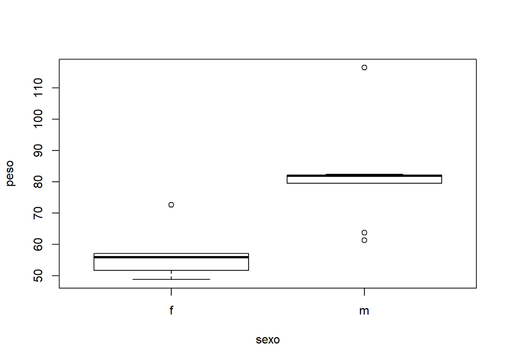

```r
boxplot(pm~dados$sexo, ylab = "peso", xlab="sexo") # homens são, em média, mais pesados que as mulheres
```

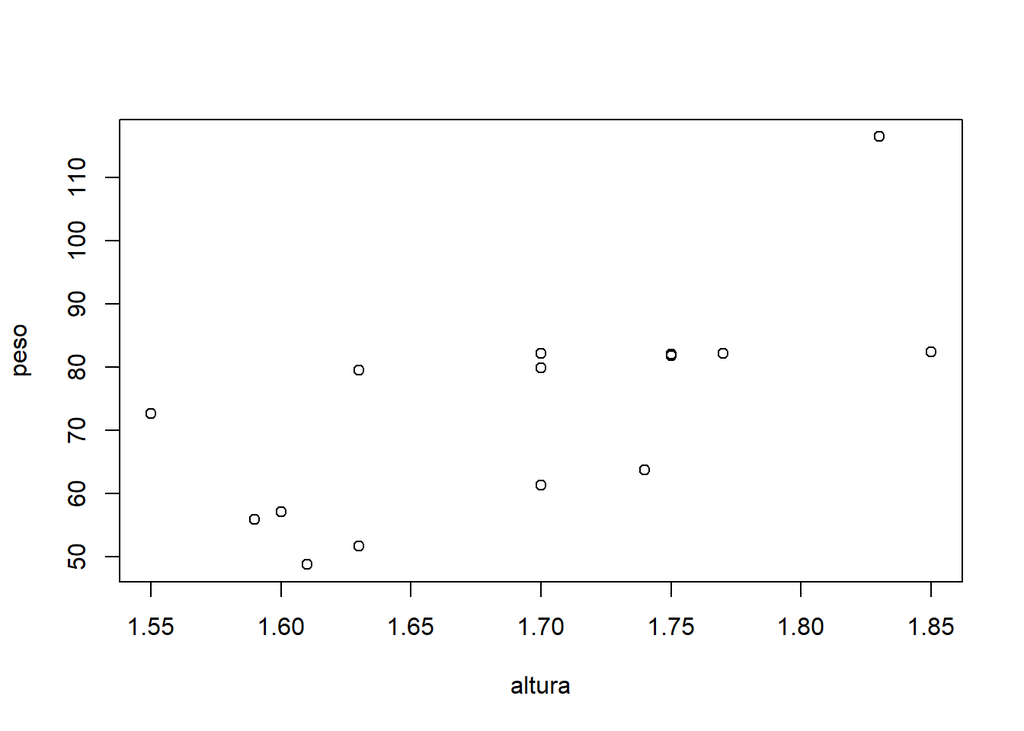

```r
plot(pm~h, ylab = "peso", xlab="altura")
```

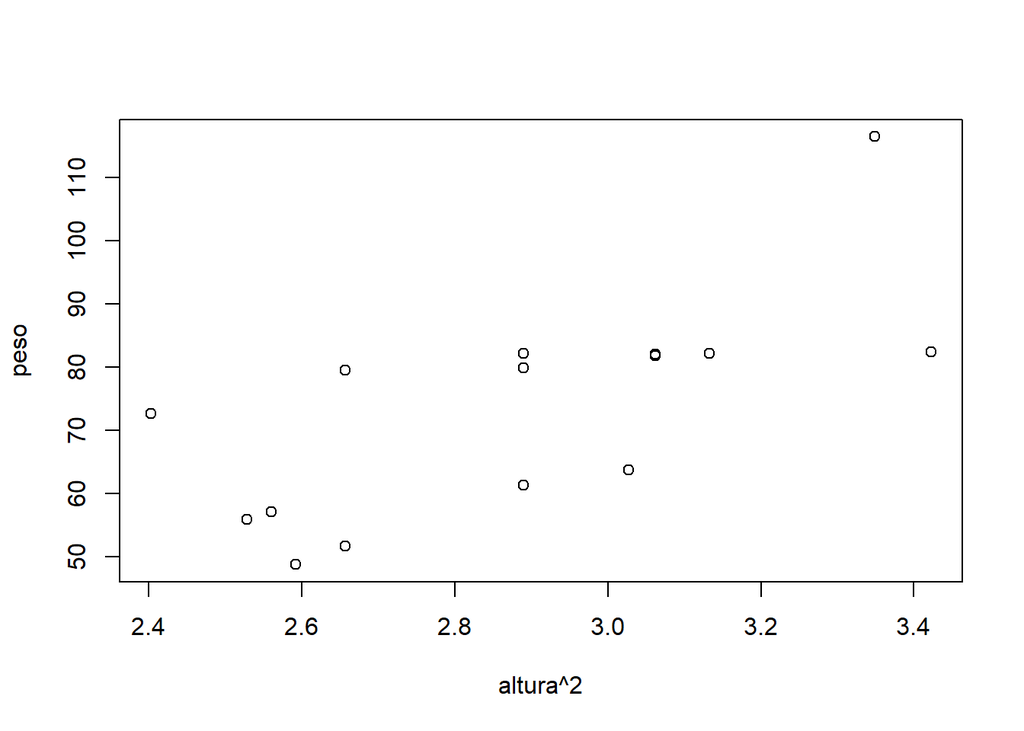

```r
h2<-h^2
plot(pm~h2, ylab = "peso", xlab="altura^2")
```

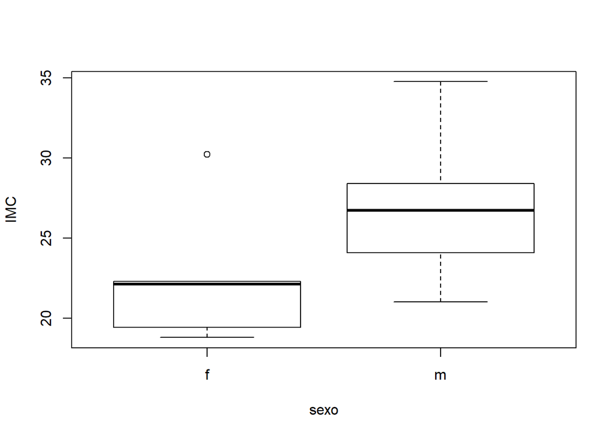

```r
# Esses gráficos corroboram uma Hipótese de estratificação f & m para analisar o IMC?????
# Duvidar é preciso. Viver não é preciso.
# Transformar sua dúvida numa hipótese testável.
# E testar adequadamente a Hipótese **contra** as observações colhidas no campo.

boxplot(IMC_m~dados$sexo, ylab = "IMC", xlab="sexo")
```

```r
#3) Número médio de caracteres dos prenomes dos alunos da turma de R que mediram seus pesos no dia 11 abr. 2018 e seu Desvio Padrão (#5)
mean(length(dados$nome))
```

```
## [1] 15
```

```r
sd(mean(length(dados$nome))) # retorna um NA. Por que?
```

```
## [1] NA
```

```r
dados$nome
```

```
##  [1] Augusto  Bernard  Carlos   Cleuler  Edson    Helber   Larissa
##  [8] Matheus  Michelly Nayana   Paula    Rafael   Tatiane  Thiago
## [15] Wesley
## 15 Levels: Augusto Bernard Carlos Cleuler Edson Helber Larissa ... Wesley
```

```r
tam_nomes<-length(dados$nome) # cuidado porque retorna o comprimento do vetor names = 15L <fctr>!!!
tam_nomes<-nchar(as.vector(dados$nome), keepNA = NA)
tam_nomes
```

```
##  [1] 7 7 6 7 5 6 7 7 8 6 5 6 7 6 6
```

```r
tam_nomes_media<-mean(tam_nomes)
tam_nomes_media
```

```
## [1] 6.4
```

```r
tam_nomes_DP   <-sd(tam_nomes)
tam_nomes_DP
```

```
## [1] 0.8280787
```

```r
#6) Quem está abaixo e acima da média mais ou menos 1 Desvio Padrão?
tam_nomes[tam_nomes<tam_nomes_media-tam_nomes_DP | tam_nomes>tam_nomes_media+tam_nomes_DP]
```

```
## [1] 5 8 5
```

```r
nomes[tam_nomes<tam_nomes_media-tam_nomes_DP | tam_nomes>tam_nomes_media+tam_nomes_DP] # Eis os nomes daqueles com tamanhos de nomes outliers da nossa turma.
```

```
## [1] Edson    Michelly Paula
## 15 Levels: Augusto Bernard Carlos Cleuler Edson Helber Larissa ... Wesley
```

```r
#7 e 8) Cálculo do IMC de cada observação desde o dia 11 abr. 2018.
#O cálculo do IMC é feito dividindo o peso (em quilogramas) pela altura (em metros) elevada ao quadrado.
IMC<-as.matrix(dados[,di:df]/dados$altura^2)
media_dp(m = IMC,dp = TRUE, row = TRUE, col = FALSE)
```

```
##       x2018.04.11 x2018.04.18 x2018.04.25 x2018.05.02 x2018.05.09
##  [1,]          NA          NA    27.61246          NA          NA 27.61246
##  [2,]    21.07280          NA    21.03977          NA    20.97371 21.02876
##  [3,]    29.92209    29.92209    30.14792    29.39516    30.11028 29.89951
##  [4,]    26.04616    25.85464    26.20575    26.81222    26.10999 26.20575
##  [5,]          NA          NA    34.75768          NA          NA 34.75768
##  [6,]    26.54694          NA    26.67755          NA    26.80816 26.67755
##  [7,]    18.90359    18.94217    18.67212    18.71070    18.74928 18.79557
##  [8,]    24.16362          NA    24.01753          NA    24.04675 24.07597
##  [9,]    22.50000          NA          NA          NA    22.07031 22.28516
## [10,]    22.26969    21.87413    22.15102    21.95325    22.30924 22.11147
## [11,]    30.13528    30.30177    30.09365    30.59313    30.05203 30.23517
## [12,]    21.48789    21.52249    21.10727    20.72664    21.10727 21.19031
## [13,]    19.79751    19.75987    19.45877    19.12003    19.04475 19.43619
## [14,]    28.40830    28.26990    28.51211    28.16609    28.71972 28.41522
```

[output cut: 17 more lines]

```r
teste.IMC<-media_dp(m = IMC,dp = TRUE, row = TRUE, col = FALSE)
IMC_m<- mean(teste.IMC[,(ncol(IMC)+1)], na.rm=TRUE) # É uma uma turma de magros!!! Conclusão precipitada?
IMC_m # = 25.17 Kg/m2 (2ª aula) # O IMC médio da turma (4ª aula) = 25.34487 indica que "ela está ligeiramente acima do peso normal" [?] - Cuidado para não "reificar" sua unidade populacional
```

```
## [1] 25.29961
```

```r
IMC_DP<-sd(teste.IMC[,(ncol(IMC)+1)], na.rm=TRUE)
IMC_DP# =  3.61 Kg/m2 (2ª aula); 4.49 Kg/m2 (2ª a 4ª aulas)
```

```
## [1] 4.531332
```

```r
IMC_m[IMC_m<18.5 | IMC_m>=25]
```

```
## [1] 25.29961
```

```r
dados$nome[IMC_m<18.5 | IMC_m>=25] # Há um problema lógico nessa expressão? Qual seria?            !!!!!!!!!!!!!!!!!!!!!!!!!!
```

```
##  [1] Augusto  Bernard  Carlos   Cleuler  Edson    Helber   Larissa
##  [8] Matheus  Michelly Nayana   Paula    Rafael   Tatiane  Thiago
## [15] Wesley
## 15 Levels: Augusto Bernard Carlos Cleuler Edson Helber Larissa ... Wesley
```

```r
boxplot(dados$altura~dados$sexo, ylab = "altura", xlab="sexo") # homens são, em média, mais alto que as mulheres
```

[output not shown]

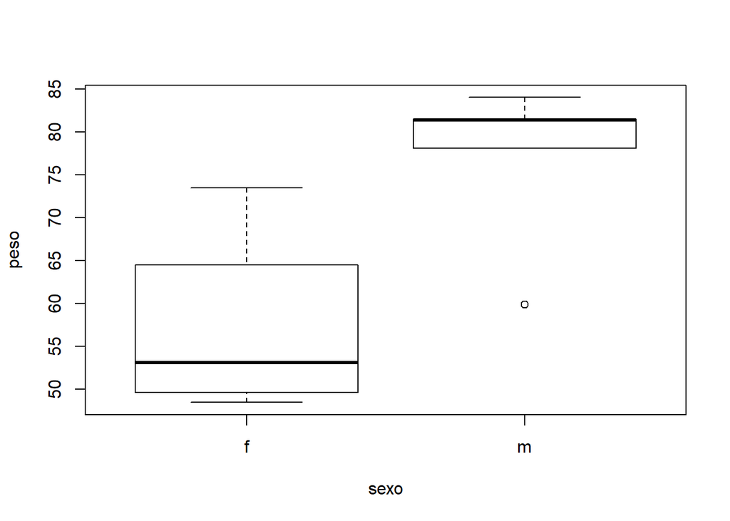

```r
boxplot(teste.peso.obs[,4]~dados$sexo, ylab = "peso", xlab="sexo") # homens são, em média, mais pesados que as mulheres
```

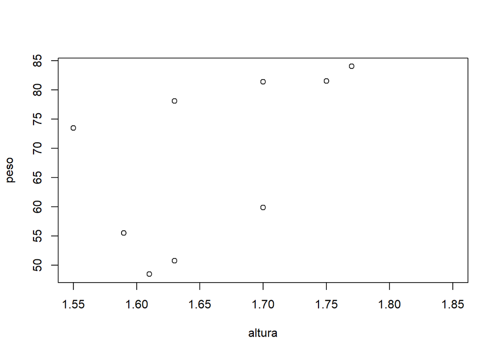

```r
plot(teste.peso.obs[,4]~dados$altura, ylab = "peso", xlab="altura")
```

```r
dados.teste<-cbind(dados,teste.peso.obs[,4:5],teste.IMC[,4:5])

boxplot(dados.teste$altura~dados.teste$sexo, ylab = "altura", xlab="sexo") # homens são, em média, mais alto que as mulheres
```

[output not shown]

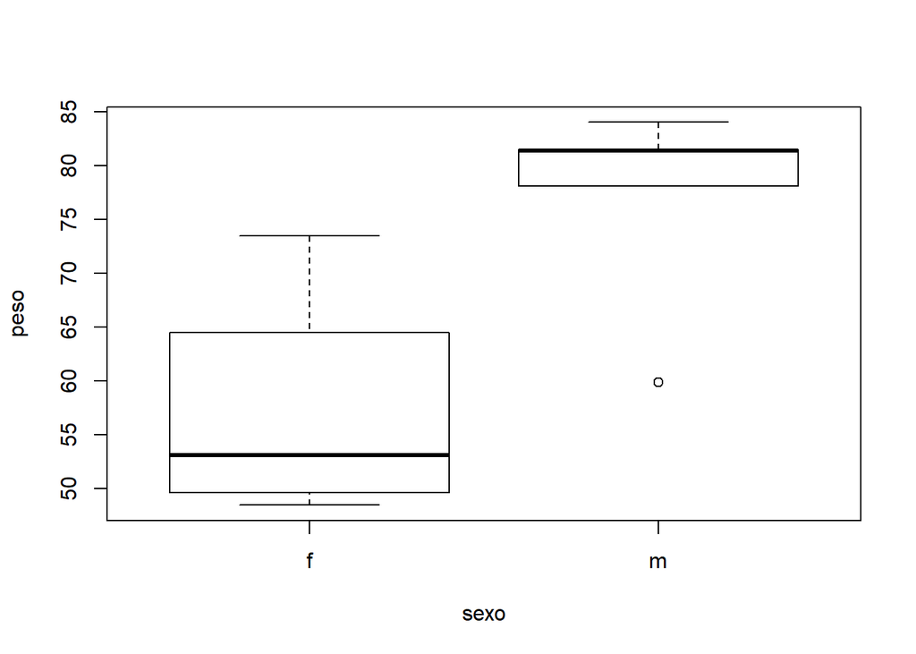

```r
boxplot(dados.teste[,13]~dados.teste$sexo, ylab = "peso", xlab="sexo") # homens são, em média, mais pesados que as mulheres
```

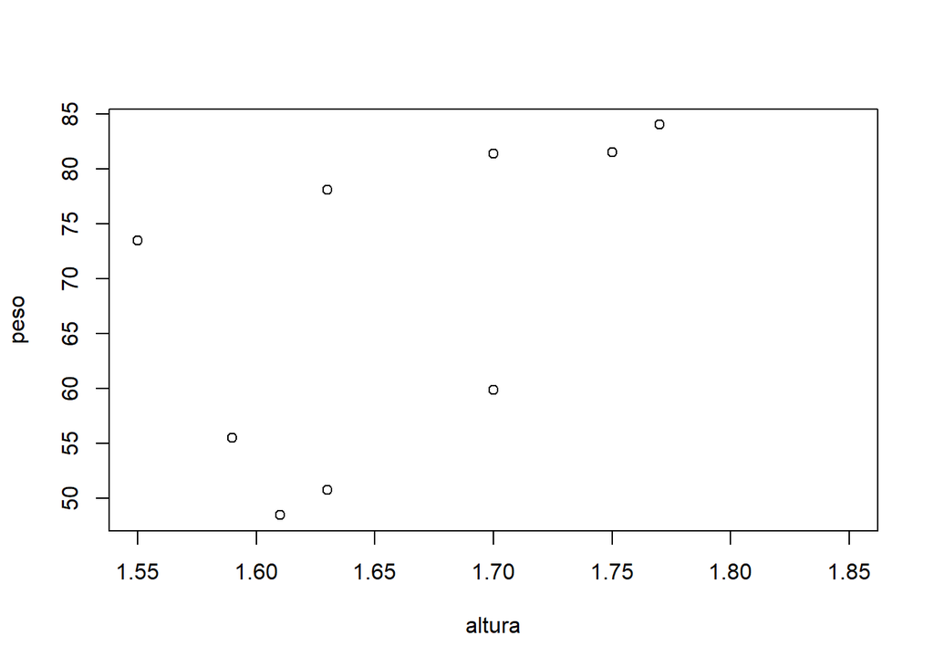

```r
plot(dados.teste[,13]~dados.teste$altura, ylab = "peso", xlab="altura")
```

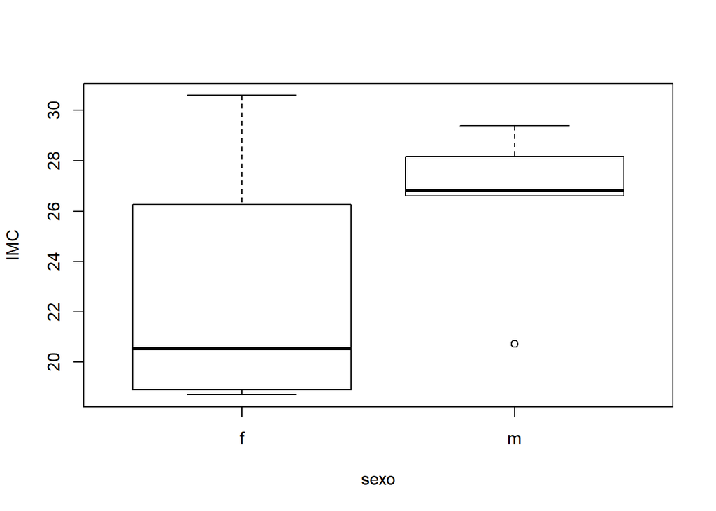

```r
boxplot(dados.teste[,15]~dados.teste$sexo, ylab = "IMC", xlab="sexo") # homens são, em média, mais alto que as mulheres
```

# Linguagem R: sua aplicabilidade e a sua funcionalidade

# uso da família apply(): sapply(), tapply(), lapply()

```r
#Criando uma função para encontrar a média e o DP de um <vctr> ou de uma <mtrx>.
#Esses valores retornarão após o último elemento do <vctr>
#Se for uma <mtrx> retornarão por linha (row=TRUE) após sua última coluna.
#ou por coluna (col=TRUE) após a última linha da <mtrx>.
media2_dp<-function(m,dp=TRUE,row=TRUE,col=TRUE) {
  if(is.vector(m)) {
#    browser()
    n<-length(m)
#        mo<-na.omit(m)
        m[n+1]<-mean(m,na.rm = TRUE)# sapply(na.omit(m),mean) não funciona como esperado porque retorna a média de cada posição de m, que é um vetor, ou seja, retorna o mesmo vector passado como argumento. Aplicando-se a regra da recilcagem, atribui o primeiro elemento 1.70 à posição n+1 do vector passado como argumento do atributo m.
    if(dp==TRUE) {
      m[n+2]<- sd(m[1:n],na.rm = TRUE) # sapply(mo,sd) e nem sapply(mo[1:n],sd)
      # Regra da Reciclagem incide em sapply() aplicando sd()!!!
      # Retorna um vetor com 15 NA's, pq não existe DP de um só valor de cada um dos elementos do vector que veio como parâmetro do argumento m
    }#fim do if(dp==TRUE)
    return(m)
  #fim do if is.vector(m)
  } else {
    l<-nrow(m)
    c<-ncol(m)

  if(is.matrix(m)) {
    if(row==TRUE) {
      # A linha seguinte é para evitar o erro: Error in `[<-`(`*tmp*`, i, c + 1, value = 79.8) : subscript out of bounds
      # Acrescendo duas colunas à matriz argumento m
      # Para armazenar a média e o DP de cada linha (row=T)
#      browser()
      m<-cbind(m,matrix(data = NA, nrow = l, ncol = 2, byrow =   FALSE,dimnames = NULL))
      #for (i in 1:l) {
        m[,c+1]<-apply(m[,1:c],1,mean,na.rm=TRUE) #mean(m[i,],na.rm = TRUE)
        if(dp==TRUE){m[,c+2]<-apply(m[,1:c],1,sd,na.rm=TRUE) #sd(m[i,1:c],na.rm = TRUE)}#fim do if
      }#fim do for para calcular média e DP de cada linha
    }#fim do if (row==TRUE)
    if(col==TRUE) {
      # A linha seguinte é para evitar o erro: Error in `[<-`(`*tmp*`, i, c + 1, value = 79.8) : subscript out of bounds
      m<-rbind(m,matrix(data = NA, nrow = 2, ncol = c, byrow =   FALSE,dimnames = NULL))
#      for (j in 1:c) {
        m[l+1,]<-apply(m[1:l,],2,mean,na.rm=TRUE) #mean(m[,j],na.rm = TRUE)
        if(dp==TRUE){m[l+2,]<-apply(m[1:l,],2,sd,na.rm=TRUE) #sd(m[1:l,j],na.rm = TRUE)}#fim do if
      }#fim do for para calcular média e DP de cada coluna
    }#fim do if (col==TRUE)
    return(m)
  }#fim do if is.matrix(m)
 }#fim do else do if is.vector(m)
}#fim da function media_dp()
```

# Linguagem R: importância de explorar a sua funcionalidade, sua **aplicabilidade** e a sua orientação a objeto

```r
#Inspecionando os dados da nossa BD
#Calculando a altura média da turma e seu desvio padrão
dados$altura
```

```
##  [1] 1.70 1.74 1.63 1.77 1.83 1.75 1.61 1.85 1.60 1.59 1.55 1.70 1.63 1.70
## [15] 1.75
```

```r
dados$altura[dados$sexo=="m"] # são 10 pessoas do sexo masculino
```

```
##  [1] 1.70 1.74 1.63 1.77 1.83 1.75 1.85 1.70 1.70 1.75
```

```r
dados$altura[dados$sexo=="f"] # são  5 pessoas do sexo feminino
```

```
## [1] 1.61 1.60 1.59 1.55 1.63
```

```r
media_dp(m = dados$altura,dp = TRUE)
```

```
##  [1] 1.70000000 1.74000000 1.63000000 1.77000000 1.83000000 1.75000000
##  [7] 1.61000000 1.85000000 1.60000000 1.59000000 1.55000000 1.70000000
## [13] 1.63000000 1.70000000 1.75000000 1.69333333 0.08973506
```

```r
media2_dp(m = dados$altura,dp = TRUE)# Testando a mesma função agora reescrita com auxílio da família apply()
```

```
##  [1] 1.70000000 1.74000000 1.63000000 1.77000000 1.83000000 1.75000000
##  [7] 1.61000000 1.85000000 1.60000000 1.59000000 1.55000000 1.70000000
## [13] 1.63000000 1.70000000 1.75000000 1.69333333 0.08973506
```

```r
media_dp(m = dados$altura[dados$sexo=="m"],dp = TRUE)
```

```
##  [1] 1.70000000 1.74000000 1.63000000 1.77000000 1.83000000 1.75000000
##  [7] 1.85000000 1.70000000 1.70000000 1.75000000 1.74200000 0.06511528
```

```r
media2_dp(m = dados$altura[dados$sexo=="m"],dp = TRUE)
```

```
##  [1] 1.70000000 1.74000000 1.63000000 1.77000000 1.83000000 1.75000000
##  [7] 1.85000000 1.70000000 1.70000000 1.75000000 1.74200000 0.06511528
```

```r
media_dp(m = dados$altura[dados$sexo=="f"],dp = TRUE)
```

```
## [1] 1.61000000 1.60000000 1.59000000 1.55000000 1.63000000 1.59600000
## [7] 0.02966479
```

```r
media2_dp(m = dados$altura[dados$sexo=="f"],dp = TRUE)
```

```
## [1] 1.61000000 1.60000000 1.59000000 1.55000000 1.63000000 1.59600000
## [7] 0.02966479
```

```r
media_dp(m = dados$x2018.04.11,dp = TRUE)
```

```
##  [1]       NA 63.80000 79.50000 81.60000       NA 81.30000 49.00000
##  [8] 82.70000 57.60000 56.30000 72.40000 62.10000 52.60000 82.10000
## [15] 81.90000 69.45385 12.87683
```

```r
media2_dp(m = dados$x2018.04.11,dp = TRUE)
```

```
##  [1]       NA 63.80000 79.50000 81.60000       NA 81.30000 49.00000
##  [8] 82.70000 57.60000 56.30000 72.40000 62.10000 52.60000 82.10000
## [15] 81.90000 69.45385 12.87683
```

```r
media2_dp(m = dados$x2018.04.18,dp = TRUE)
```

```
##  [1]       NA       NA 79.50000 81.00000       NA       NA 49.10000
##  [8]       NA       NA 55.30000 72.80000 62.20000 52.50000 81.70000
## [15] 83.20000 68.58889 13.83966
```

```r
media2_dp(m = dados$x2018.04.25,dp = TRUE)
```

```
##  [1]  79.80000  63.70000  80.10000  82.10000 116.40000  81.70000  48.40000
##  [8]  82.20000        NA  56.00000  72.30000  61.00000  51.70000  82.40000
## [15]        NA  73.67692  17.99209
```

```r
media2_dp(m = dados$x2018.05.02,dp = TRUE)
```

```
##  [1]       NA       NA 78.10000 84.00000       NA       NA 48.50000
##  [8]       NA       NA 55.50000 73.50000 59.90000 50.80000 81.40000
## [15] 81.50000 68.13333 14.35209
```

```r
#Observa-se uma forte oscilação na média de peso da turma em cada observação, em razão das faltas sistemáticas de alguns alunos
# Como evitar que esse fato interfira na tentativa de observar se uma simples recomendação de adoção de uma dieta do meio, do terço ou da sesma é ou não capaz de alterar a média do peso da turma ao longo de um curso de R com 10 semanas de duração?


################################################################
################################################################
################################################################
#Testando a mesma função para <obj> <mtrx> como parâmetro
# verificando o peso médio e o DP para cada aluno desde a 2ª aula
media_dp(m = as.matrix(dados[,di:df]),dp = TRUE, row = TRUE, col = FALSE) # é necessário transformar dados <data.frame> em <mtrx> porque senão o teste is.matrix resultará em FALSE na função chamada
```

```
##       x2018.04.11 x2018.04.18 x2018.04.25 x2018.05.02 x2018.05.09
##  [1,]          NA          NA        79.8          NA          NA
##  [2,]        63.8          NA        63.7          NA        63.5
##  [3,]        79.5        79.5        80.1        78.1        80.0
##  [4,]        81.6        81.0        82.1        84.0        81.8
##  [5,]          NA          NA       116.4          NA          NA
##  [6,]        81.3          NA        81.7          NA        82.1
##  [7,]        49.0        49.1        48.4        48.5        48.6
##  [8,]        82.7          NA        82.2          NA        82.3
##  [9,]        57.6          NA          NA          NA        56.5
## [10,]        56.3        55.3        56.0        55.5        56.4
## [11,]        72.4        72.8        72.3        73.5        72.2
## [12,]        62.1        62.2        61.0        59.9        61.0
## [13,]        52.6        52.5        51.7        50.8        50.6
## [14,]        82.1        81.7        82.4        81.4        83.0
```

[output cut: 17 more lines]

```r
media2_dp(m = as.matrix(dados[,di:df]),dp = TRUE, row = TRUE, col = FALSE)
```

```
##       x2018.04.11 x2018.04.18 x2018.04.25 x2018.05.02 x2018.05.09
##  [1,]          NA          NA        79.8          NA          NA
##  [2,]        63.8          NA        63.7          NA        63.5
##  [3,]        79.5        79.5        80.1        78.1        80.0
##  [4,]        81.6        81.0        82.1        84.0        81.8
##  [5,]          NA          NA       116.4          NA          NA
##  [6,]        81.3          NA        81.7          NA        82.1
##  [7,]        49.0        49.1        48.4        48.5        48.6
##  [8,]        82.7          NA        82.2          NA        82.3
##  [9,]        57.6          NA          NA          NA        56.5
## [10,]        56.3        55.3        56.0        55.5        56.4
## [11,]        72.4        72.8        72.3        73.5        72.2
## [12,]        62.1        62.2        61.0        59.9        61.0
## [13,]        52.6        52.5        51.7        50.8        50.6
## [14,]        82.1        81.7        82.4        81.4        83.0
```

[output cut: 17 more lines]

```r
teste.peso.obs<-media2_dp(m = as.matrix(dados[,di:df]),dp = TRUE, row = TRUE, col = FALSE)

teste.peso.aula<-media2_dp(m = as.matrix(dados[,di:df]),dp = TRUE, row = FALSE, col = TRUE)
teste.peso.aula
```

```
##       x2018.04.11 x2018.04.18 x2018.04.25 x2018.05.02 x2018.05.09
##  [1,]          NA          NA    79.80000          NA          NA
##  [2,]    63.80000          NA    63.70000          NA    63.50000
##  [3,]    79.50000    79.50000    80.10000    78.10000    80.00000
##  [4,]    81.60000    81.00000    82.10000    84.00000    81.80000
##  [5,]          NA          NA   116.40000          NA          NA
##  [6,]    81.30000          NA    81.70000          NA    82.10000
##  [7,]    49.00000    49.10000    48.40000    48.50000    48.60000
##  [8,]    82.70000          NA    82.20000          NA    82.30000
##  [9,]    57.60000          NA          NA          NA    56.50000
## [10,]    56.30000    55.30000    56.00000    55.50000    56.40000
## [11,]    72.40000    72.80000    72.30000    73.50000    72.20000
## [12,]    62.10000    62.20000    61.00000    59.90000    61.00000
## [13,]    52.60000    52.50000    51.70000    50.80000    50.60000
## [14,]    82.10000    81.70000    82.40000    81.40000    83.00000
## [15,]    81.90000    83.20000          NA    81.50000    81.30000
## [16,]    69.45385    68.58889    73.67692    68.13333    69.17692
## [17,]    12.87683    13.83966    17.99209    14.35209    13.39914
```

```r
media_dp(m = as.matrix(dados[,di:df]),dp = TRUE, row = FALSE, col = TRUE)
```

```
##       x2018.04.11 x2018.04.18 x2018.04.25 x2018.05.02 x2018.05.09
##  [1,]          NA          NA    79.80000          NA          NA
##  [2,]    63.80000          NA    63.70000          NA    63.50000
##  [3,]    79.50000    79.50000    80.10000    78.10000    80.00000
##  [4,]    81.60000    81.00000    82.10000    84.00000    81.80000
##  [5,]          NA          NA   116.40000          NA          NA
##  [6,]    81.30000          NA    81.70000          NA    82.10000
##  [7,]    49.00000    49.10000    48.40000    48.50000    48.60000
##  [8,]    82.70000          NA    82.20000          NA    82.30000
##  [9,]    57.60000          NA          NA          NA    56.50000
## [10,]    56.30000    55.30000    56.00000    55.50000    56.40000
## [11,]    72.40000    72.80000    72.30000    73.50000    72.20000
## [12,]    62.10000    62.20000    61.00000    59.90000    61.00000
## [13,]    52.60000    52.50000    51.70000    50.80000    50.60000
## [14,]    82.10000    81.70000    82.40000    81.40000    83.00000
## [15,]    81.90000    83.20000          NA    81.50000    81.30000
## [16,]    69.45385    68.58889    73.67692    68.13333    69.17692
## [17,]    12.87683    13.83966    17.99209    14.35209    13.39914
```

```r
#Verificando se a média das médias dos pesos por dia de aula é a mesma da média das médias dos pesos por aluno
media_dp(m=as.vector(teste.peso.obs[,4]),dp=TRUE)
```

```
##  [1]       NA       NA 78.10000 84.00000       NA       NA 48.50000
##  [8]       NA       NA 55.50000 73.50000 59.90000 50.80000 81.40000
## [15] 81.50000 68.13333 14.35209
```

```r
media_dp(m=as.vector(teste.peso.aula[16,]),dp=TRUE)
```

```
## [1] 69.453846 68.588889 73.676923 68.133333 69.176923 69.805983  2.223902
```

```r
#Resultado: nem a média nem o desvio padrão resutaram os mesmos!!!
#Era esperado que não resultasse o mesmo desvio padrão (NA's)
#Mas é refoge às expectativas que não resulte na mesma média dos pesos
# Ocorre que com nem todos os alunos compareceram a todas as aulas, então o número de observações do peso de cada um deles varia e, assim, varia o denominador para o cálculo da média de cada um dos faltantes. Cada aluno que falta provoca uma oscilação no valor da média do peso em cada dia de aula e uma alteração de seu denominador.
```